# Introduction to Biostatistics

# 1 Learning objectives

## 1.1 Learning objectives

- *Describe* the logic of ANOVA
- *Conduct* and *interpret* the overall ANOVA test
- *Conduct* post hoc tests

# 2 Extending the $t$-test

## 2.1 Review: $t$-test

- Compare exactly **2 groups**
- Focus on **difference** between group **means**
- $t$ distribution
- Statistical test: difference / standard error

## 2.2 ANOVA compares 3+ groups

- Medication: Control, low dose, high dose
- Treatment: Usual care, new treatment 1, new treatment 2
- Modality: In-person, online, hybrid

## 2.3 2 group approaches…

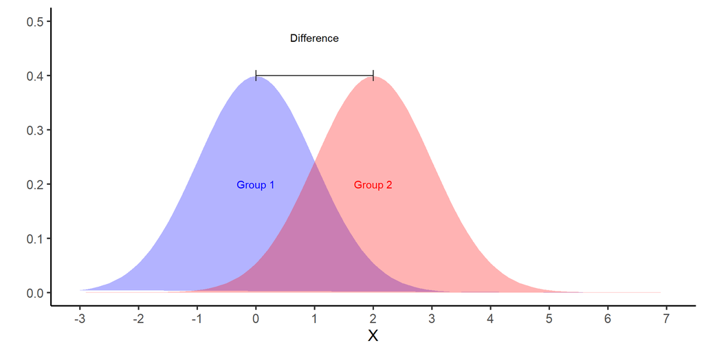

```r
ggplot(data.frame(x = c(-3, 7)), aes(x)) +
  stat_function(fun = dnorm, args = list(mean = 0, sd = 1),
                geom = "polygon",
                alpha = 0.3,
                fill = "blue") +
  stat_function(fun = dnorm, args = list(mean = 2, sd = 1),
                geom = "polygon",
                alpha = 0.3,
                fill = "red") +
  ylim(0,.5) +
  scale_x_continuous(breaks = -3:7) +
  labs(x = "X", y = "") +
  annotate("text", x = 0, y = 0.2, label = "Group 1", color = "blue") +
  annotate("text", x = 2, y = 0.2, label = "Group 2", color = "red") +
  annotate("segment", x = 0,, xend = 2, y = .4, yend = .4,
           arrow = arrow(ends = "both", angle = 90, length = unit(.2,"cm"))) +
  annotate("text", x = 1, y = .47, label = "Difference")
```

## 2.4 … don’t extend well to 3+ groups

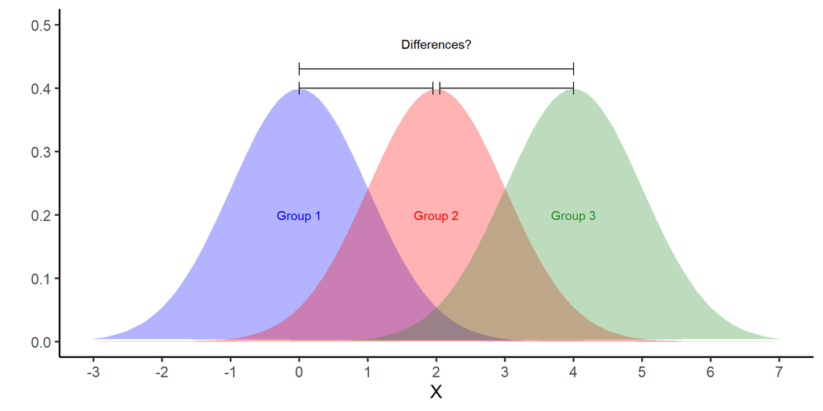

```r
ggplot(data.frame(x = c(-3, 7)), aes(x)) +
  stat_function(fun = dnorm, args = list(mean = 0, sd = 1),
                geom = "polygon",
                alpha = 0.3,
                fill = "blue") +
  stat_function(fun = dnorm, args = list(mean = 2, sd = 1),
                geom = "polygon",
                alpha = 0.3,
                fill = "red") +
  stat_function(fun = dnorm, args = list(mean = 4, sd = 1),
                geom = "polygon",
                alpha = 0.3,
                fill = "forestgreen") +
  ylim(0,.5) +
  scale_x_continuous(breaks = -3:7) +
  labs(x = "X", y = "") +
  annotate("text", x = 0, y = 0.2, label = "Group 1", color = "blue") +
  annotate("text", x = 2, y = 0.2, label = "Group 2", color = "red") +
  annotate("text", x = 4, y = 0.2, label = "Group 3", color = "forestgreen") +
  annotate("segment", x = 0, xend = 1.95, y = .4, yend = .4,
           arrow = arrow(ends = "both", angle = 90, length = unit(.2,"cm"))) +
  annotate("text", x = 2, y = .47, label = "Differences?") +
  annotate("segment", x = 2.05, xend = 4, y = .4, yend = .4,
           arrow = arrow(ends = "both", angle = 90, length = unit(.2,"cm"))) +
  annotate("segment", x = 0, xend = 4, y = .43, yend = .43,
           arrow = arrow(ends = "both", angle = 90, length = unit(.2,"cm")))
```

# 3 Between-subjects ANOVA

## 3.1 Logic

- Extension of independent samples $t$-test
- **Sources of variability** instead of differences
  - Variability *across groups*
  - Variability across individuals *within a group* (random error)
- Is the *variability across groups* (i.e., mean differences) **large** in the context of the *within-group variability*?
  - Signal to noise ratio

## 3.2 Between > within

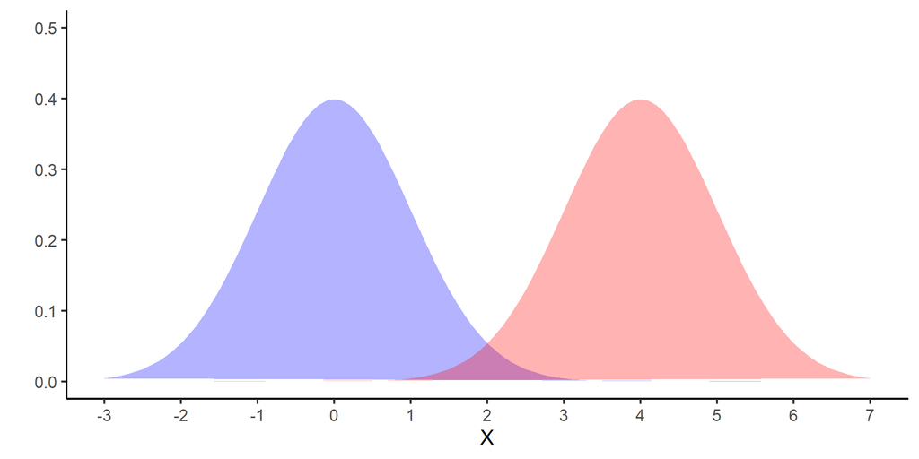

```r
ggplot(data.frame(x = c(-3, 7)), aes(x)) +
  stat_function(fun = dnorm, args = list(mean = 0, sd = 1),
                geom = "polygon",
                alpha = 0.3,
                fill = "blue") +
  stat_function(fun = dnorm, args = list(mean = 4, sd = 1),
                geom = "polygon",
                alpha = 0.3,
                fill = "red") +
  ylim(0,.5) +
  scale_x_continuous(breaks = -3:7) +
  labs(x = "X", y = "")
```

## 3.3 Within > between

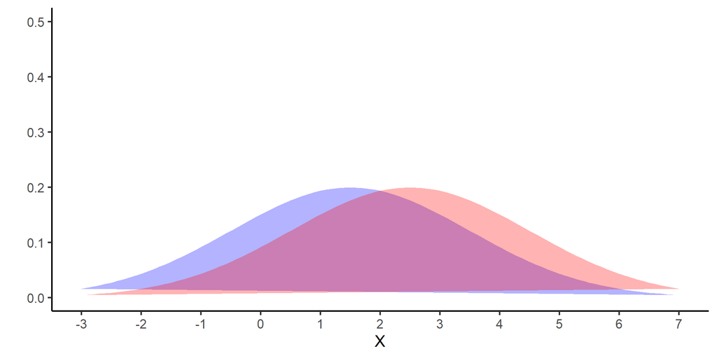

```r
ggplot(data.frame(x = c(-3, 7)), aes(x)) +
  stat_function(fun = dnorm, args = list(mean = 1.5, sd = 2),
                geom = "polygon",
                alpha = 0.3,
                fill = "blue") +
  stat_function(fun = dnorm, args = list(mean = 2.5, sd = 2),
                geom = "polygon",
                alpha = 0.3,
                fill = "red") +
  ylim(0,.5) +
  scale_x_continuous(breaks = -3:7) +
  labs(x = "X", y = "")
```

## 3.4 Total variance

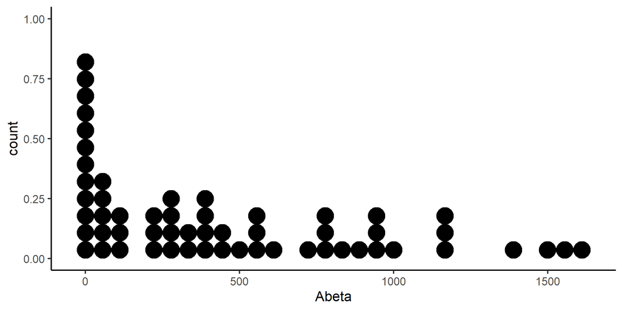

```r
library(Stat2Data)
data(Amyloid)
#head(Amyloid)
ggplot(data = Amyloid, aes(x = Abeta)) +
  geom_dotplot(method = "histodot") +
  theme(legend.position="none")
```

## 3.5 Partitioned variance

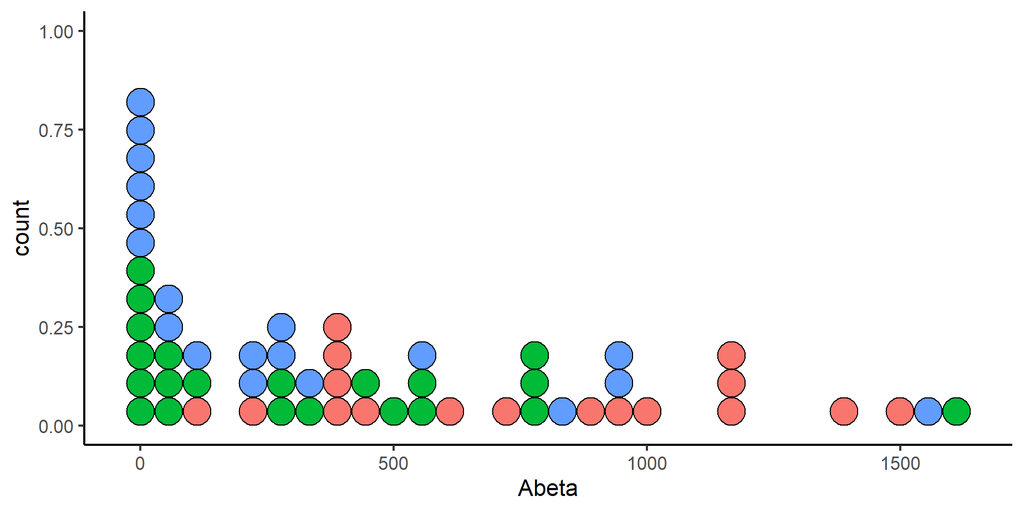

```r
ggplot(data = Amyloid, aes(x = Abeta, fill= Group)) +
  geom_dotplot(method = "histodot", stackgroups = TRUE) +
  theme(legend.position="none")
```

## 3.6 Partitioned variance

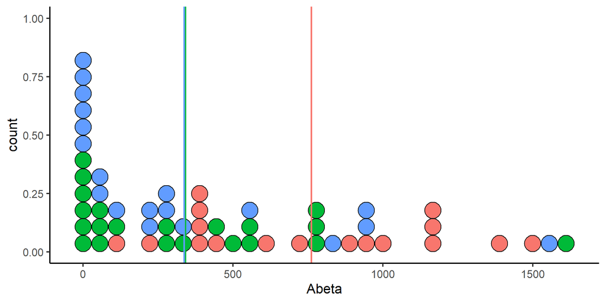

```r
means <- Amyloid %>% group_by(Group) %>% summarize(meanAbeta = mean(Abeta))
ggplot(data = Amyloid, aes(x = Abeta, fill= Group)) +
  geom_dotplot(method = "histodot", stackgroups = TRUE) +
  theme(legend.position="none") +
  geom_vline(aes(xintercept = means$meanAbeta[1]),
             color = "#F8766D",
             linewidth = 1) +
  geom_vline(aes(xintercept = means$meanAbeta[2]),
             color = "#00BA38",
             linewidth = 1) +
  geom_vline(aes(xintercept = means$meanAbeta[3]),
             color = "#619CFF",
             linewidth = 1)
```

## 3.7 Assumptions

- One *categorical* (grouping) variable with 3+ categories
- One *continuous* (i.e., interval or ratio) variable
- Data are *randomly sampled* from the population
- Data are *independent* (within and across groups)
- Data are approximately *normally distributed* OR *sample size is large enough* for normally distributed sampling distribution
  - Residuals from model are **normally distributed**
- Population *variance* is unknown and *same in all groups*

## 3.8 Hypotheses

- $H_0$: All means are equal
  - $\mu_1 = \mu_2 = \mu_3$
- $H_1$: **At least one mean** is different from the others
  - (**NOT** $\mu_1 \ne \mu_2 \ne \mu_3$)

## 3.9 ANOVA summary table

| Source of variation | Sums of squares (SS) | df | Mean squares (MS) | F |
| --- | --- | --- | --- | --- |
| Between | $SS_{between}$ | $k - 1$ | $MS_{between}$ | $F$ |
| Error | $SS_{error}$ | $N - k$ | $MS_{error}$ |  |
| Total | $SS_{total}$ | $N - 1$ |  |  |

- $k$ = number of groups
- $N$ = total number of participants
- $n$ = number of participants in a group

## 3.10 Test statistic 1: Sums of squares

- $SS_{between}$ = variation of $\color{red}{group\ means}$ around $\color{blue}{grand\ mean}$
  - $SS_{between} = \Sigma_{1}^{k} (\color{red}{\bar{X}_j} - \color{blue}{\bar{X}})^2$
- $SS_{error}$ = variation of $individual\ values$ around $\color{red}{group\ means}$
  - $SS_{error} = \Sigma_{1}^{k}\Sigma_{1}^{n} (X - \color{red}{\bar{X}_j})^2$
- $SS_{total}$ = variation of $individual\ values$ around $\color{blue}{grand\ mean}$
  - $SS_{total} = \Sigma_{1}^N (X - \color{blue}{\bar{X}})^2$
- $SS_{total} = SS_{between} + SS_{error}$

## 3.11 Test statistic 2: Mean squares

Mean squares = Sum of squares divided by degrees of freedom

- $MS_{between}$ = **between group variance**
  - $MS_{between} = \frac{SS_{between}}{k - 1}$
- $MS_{error}$ = **within group variance**
  - $MS_{error} = \frac{SS_{error}}{N-k}$

## 3.12 Test statistic 3: $F$-statistic

Analysis of “variance” = compare **variances**

- $F$-statistic = **between group variance** / **within group variance**
  - $F = \frac{MS_{between}}{MS_{error}}$
- Compare to critical $F$ from a distribution of $k - 1$ and $N - k$ degrees of freedom
  - If the observed $F$ statistic is larger, reject $H_0$
  - Otherwise, retain $H_0$

## 3.13 $F$ distribution

- Two different degrees of freedom values
  - First is about the number of **groups**: $k - 1$
  - Second is about the number of **subjects (and groups)**: $N - k$

**Note**

- Compare to $t$ distribution
  - Just a single df value
  - Always only comparing 2 groups
  - $[t(df)]^2 = F(1, df)$

## 3.14 $F$ distribution

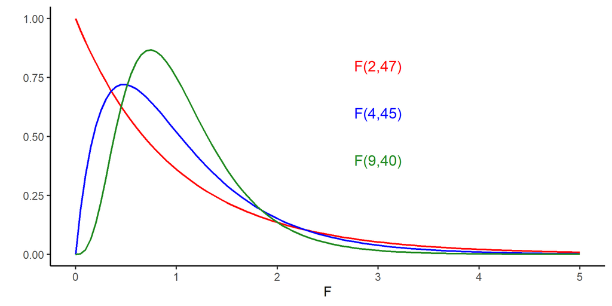

```r
ggplot(data.frame(x = c(0, 5)), aes(x)) +
  stat_function(fun = df,
                args = list(df1 = 2, df2 = 47),
                geom = "line",
                linewidth = 1,
                color = "red") +
  stat_function(fun = df,
                args = list(df1 = 4, df2 = 45),
                geom = "line",
                linewidth = 1,
                 color = "blue") +
stat_function(fun = df,
              args = list(df1 = 9, df2 = 40),
              geom = "line",
              linewidth = 1,
              color = "forestgreen") +
  scale_x_continuous(breaks = 0:5) +
  labs(x = "F", y = "") +
  annotate("text",
           x = 3, y = 0.8,
           label = "F(2,47)",
           color = "red",
           size = 6) +
  annotate("text",
           x = 3, y = 0.6,
           label = "F(4,45)",
           color = "blue",
           size = 6) +
  annotate("text",
           x = 3, y = 0.4,
           label = "F(9,40)",
           color = "forestgreen",
           size = 6)
```

- 50 subjects in 3 vs 5 vs 10 groups

## 3.15 Example data

- $N$ = 57 observations on the following 2 variables.
  - `Group`
    - `mAD`=Alzheimer’s disease
    - `MCI`=mild impairment
    - `NCI`=no impairment
  - `Abeta`
    - Amount of amyloid beta from the posterior cingulate cortex (pmol/g tissue)

## 3.16 Example data

```r
Amyloid %>% group_by(Group) %>%
  summarize(mean = mean(Abeta),
            variance = var(Abeta)) %>%
  kable()
```

| Group | mean | variance |
| --- | --- | --- |
| mAD | 761.2941 | 182068.0 |
| MCI | 341.0476 | 165168.4 |
| NCI | 336.2632 | 189755.8 |

## 3.17 Check assumptions: Equal variance

- Graphically

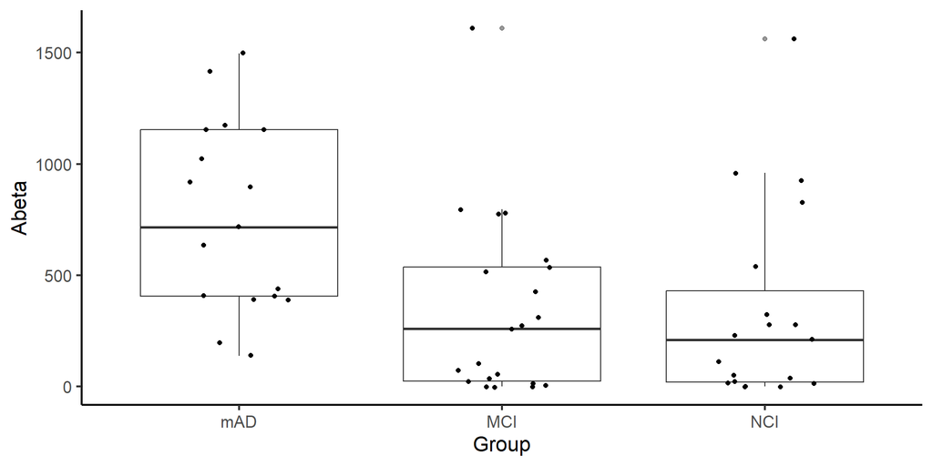

```r
ggplot(data = Amyloid,
       aes(x = Group, y = Abeta)) +
  geom_boxplot(alpha = 0.5) +
  geom_jitter(width = 0.2)
```

- `leveneTest()` in **car** package

```r
library(car)
leveneTest(Abeta ~ Group, data = Amyloid)
```

```
Levene's Test for Homogeneity of Variance (center = median)
      Df F value Pr(>F)
group  2  0.3505 0.7059
      54
```

- $H_0$: No differences in variances across groups
  - NS result = equal variances

## 3.18 Example: ANOVA

```r
m1 <- lm(Abeta ~ Group,
         contrasts=list(Group='contr.sum'),
         data = Amyloid)
anova(m1)
```

```
Analysis of Variance Table

Response: Abeta
          Df  Sum Sq Mean Sq F value   Pr(>F)
Group      2 2129969 1064985  5.9706 0.004544 **
Residuals 54 9632060  178371
---
Signif. codes:  0 '***' 0.001 '**' 0.01 '*' 0.05 '.' 0.1 ' ' 1
```

- We reject the null hypothesis that all means are equal, F(2, 54) = 5.9706, p = .0045. **At least one group mean is different from the others.**

## 3.19 Type I vs III sums of squares

- **Type III sums of squares** are “corrected sums of squares”
  - How ANOVA is taught, default in every software package except R
- **Type I sums of squares** are “uncorrected sums of squares”
  - Default in R
- Different interpretations
  - But not different numerically **if all groups are the same size**
  - Type III recommended by *almost* everyone when groups are different sizes

## 3.20 Assumptions: Normality

- Graphically

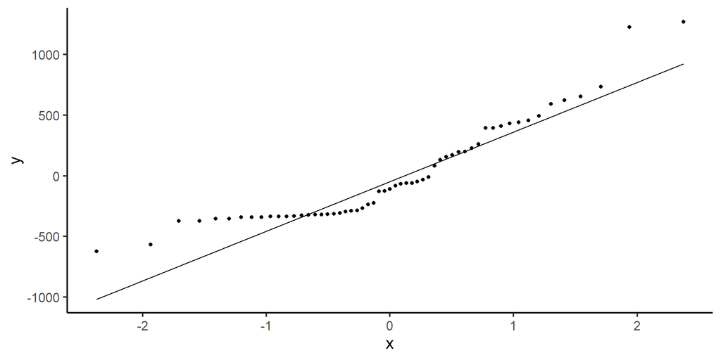

```r
m1resid <- data.frame(residuals(m1))
ggplot(data = m1resid,
       aes(sample = residuals.m1.)) +
  geom_qq() +
  geom_qq_line()
```

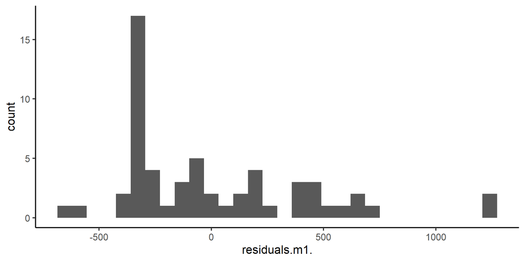

```r
m1resid <- data.frame(residuals(m1))
ggplot(data = m1resid,
       aes(x = residuals.m1.)) +
  geom_histogram()
```

- `shapiro.test()` in **stats**

```r
shapiro.test(resid(m1))
```

```
    Shapiro-Wilk normality test

data:  resid(m1)
W = 0.88246, p-value = 0.00004857
```

- $H_0$: Observations come from normally distributed population
  - NS result = normally distributed residuals

## 3.21 Post hoc tests

- Significant overall (omnibus) test for ANOVA means
  - *At least one group mean* is different from the others
  - But **which one(s)**?
- Post hoc tests
  - Figure out which means are different from one another
  - But not all possible tests, only specific ones

## 3.22 Post hoc tests

- Conceptually, a series of $t$-tests
  - Use standard error estimate based on **whole model** instead of standard error estimate from just the two groups
  - Context of whole model
    - Not just some random set of 2 group comparisons

## 3.23 Contrasts for post hoc tests

- Many built-in contrasts for specific patterns
  - Four common: dummy, deviation, polynomial, Helmert
  - Also: User-specified contrasts
- Contrasts / weights: [UCLA Statistical Consulting](https://stats.oarc.ucla.edu/r/library/r-library-contrast-coding-systems-for-categorical-variables/)
- ANOVA table is the **same** regardless of which contrasts you use
  - `summary()` of model will give you mean differences

## 3.24 Example again: ANOVA

```r
m1 <- lm(Abeta ~ Group,
         contrasts=list(Group='contr.sum'),
         data = Amyloid)
anova(m1)
```

```
Analysis of Variance Table

Response: Abeta
          Df  Sum Sq Mean Sq F value   Pr(>F)
Group      2 2129969 1064985  5.9706 0.004544 **
Residuals 54 9632060  178371
---
Signif. codes:  0 '***' 0.001 '**' 0.01 '*' 0.05 '.' 0.1 ' ' 1
```

## 3.25 Contrasts: Dummy / `treatment`

- Compare each group to a specific group (e.g., control)

|  | mAD v MCI | mAD v NCI |
| --- | --- | --- |
| mAD | 0 | 0 |
| MCI | 1 | 0 |
| NCI | 0 | 1 |

- Default reference: First

## 3.26 Contrasts: Dummy / `treatment`

```r
m1_trt <- lm(Abeta ~ Group,
         contrasts=list(Group='contr.treatment'),
         data = Amyloid)
#anova(m1_trt)
summary(m1_trt)
```

```
Call:
lm(formula = Abeta ~ Group, data = Amyloid, contrasts = list(Group = "contr.treatment"))

Residuals:
   Min     1Q Median     3Q    Max
-623.3 -322.3 -108.3  227.9 1269.0

Coefficients:
            Estimate Std. Error t value       Pr(>|t|)
(Intercept)    761.3      102.4   7.432 0.000000000819 ***
GroupMCI      -420.2      137.8  -3.050        0.00354 **
GroupNCI      -425.0      141.0  -3.014        0.00392 **
---
Signif. codes:  0 '***' 0.001 '**' 0.01 '*' 0.05 '.' 0.1 ' ' 1

Residual standard error: 422.3 on 54 degrees of freedom
Multiple R-squared:  0.1811,    Adjusted R-squared:  0.1508
F-statistic: 5.971 on 2 and 54 DF,  p-value: 0.004544
```

## 3.27 Contrasts: Deviation / `sum`

- Compare each group (except one) to *unweighted* grand mean
  - $(\bar{X}_1 + \bar{X}_2 + \bar{X}_3)/3$

|  | mAD v GM | MCI v GM |
| --- | --- | --- |
| mAD | 1 | 0 |
| MCI | 0 | 1 |
| NCI | -1 | -1 |

- Default left out: Last

## 3.28 Contrasts: Deviation / `sum`

```r
m1_sum <- lm(Abeta ~ Group,
         contrasts=list(Group='contr.sum'),
         data = Amyloid)
#anova(m1_sum)
summary(m1_sum)
```

```
Call:
lm(formula = Abeta ~ Group, data = Amyloid, contrasts = list(Group = "contr.sum"))

Residuals:
   Min     1Q Median     3Q    Max
-623.3 -322.3 -108.3  227.9 1269.0

Coefficients:
            Estimate Std. Error t value        Pr(>|t|)
(Intercept)   479.53      56.15   8.540 0.0000000000134 ***
Group1        281.76      81.55   3.455         0.00108 **
Group2       -138.49      77.36  -1.790         0.07902 .
---
Signif. codes:  0 '***' 0.001 '**' 0.01 '*' 0.05 '.' 0.1 ' ' 1

Residual standard error: 422.3 on 54 degrees of freedom
Multiple R-squared:  0.1811,    Adjusted R-squared:  0.1508
F-statistic: 5.971 on 2 and 54 DF,  p-value: 0.004544
```

## 3.29 Contrasts: Polynomial / `poly`

- Linear, quadatric, etc. effects (orthogonal)

|  | Linear | Quadratic |
| --- | --- | --- |
| mAD | -1 | 1 |
| MCI | 0 | -2 |
| NCI | 1 | 1 |

- Only useful with ordered levels (none, low, high)

## 3.30 Contrasts: Polynomial / `poly`

```r
m1_poly <- lm(Abeta ~ Group,
              contrasts=list(Group='contr.poly'),
              data = Amyloid)
#anova(m1_poly)
summary(m1_poly)
```

```
Call:
lm(formula = Abeta ~ Group, data = Amyloid, contrasts = list(Group = "contr.poly"))

Residuals:
   Min     1Q Median     3Q    Max
-623.3 -322.3 -108.3  227.9 1269.0

Coefficients:
            Estimate Std. Error t value        Pr(>|t|)
(Intercept)   479.53      56.15   8.540 0.0000000000134 ***
Group.L      -300.54      99.70  -3.014         0.00392 **
Group.Q       169.61      94.74   1.790         0.07902 .
---
Signif. codes:  0 '***' 0.001 '**' 0.01 '*' 0.05 '.' 0.1 ' ' 1

Residual standard error: 422.3 on 54 degrees of freedom
Multiple R-squared:  0.1811,    Adjusted R-squared:  0.1508
F-statistic: 5.971 on 2 and 54 DF,  p-value: 0.004544
```

## 3.31 Contrasts: Helmert / `helmert`

- Compare 1st to mean of 2 to k, 2nd to mean of 3 to k, etc.

|  | mAD v MCI | mAD v NCI |
| --- | --- | --- |
| mAD | 2/3 | 0 |
| MCI | -1/3 | 1/2 |
| NCI | -1/3 | -1/2 |

## 3.32 Contrasts: Helmert / `helmert`

```r
m1_helm <- lm(Abeta ~ Group,
              contrasts=list(Group='contr.helmert'),
              data = Amyloid)
#anova(m1_helm)
summary(m1_helm)
```

```
Call:
lm(formula = Abeta ~ Group, data = Amyloid, contrasts = list(Group = "contr.helmert"))

Residuals:
   Min     1Q Median     3Q    Max
-623.3 -322.3 -108.3  227.9 1269.0

Coefficients:
            Estimate Std. Error t value        Pr(>|t|)
(Intercept)   479.53      56.15   8.540 0.0000000000134 ***
Group1       -210.12      68.90  -3.050         0.00354 **
Group2        -71.64      39.63  -1.808         0.07623 .
---
Signif. codes:  0 '***' 0.001 '**' 0.01 '*' 0.05 '.' 0.1 ' ' 1

Residual standard error: 422.3 on 54 degrees of freedom
Multiple R-squared:  0.1811,    Adjusted R-squared:  0.1508
F-statistic: 5.971 on 2 and 54 DF,  p-value: 0.004544
```

## 3.33 Mean comparisons

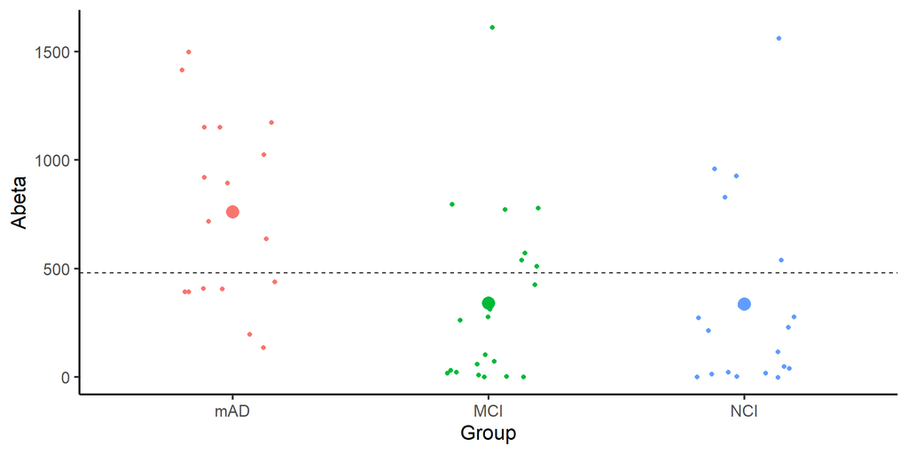

```r
ggplot(data = Amyloid,
       aes(x = Group,
           y = Abeta,
           color = Group)) +
  geom_jitter(width = 0.2) +
  geom_point(data = means,
             aes(x = Group,
                 y = meanAbeta,
                 color = Group,
                 size = 10)) +
  geom_hline(yintercept = sum(means$meanAbeta)/3,
             linetype = "dashed") +
  theme(legend.position="none")
```

- Dummy: mAD v MCI, mAD v NCI
- Sum: mAD v GM, **not** MCI v GM
- Poly: Linear, **not** quadratic
- Helmert: 1 v 2&3, **not** 2 v 3

## 3.34 Should you correct for that?

- Arguments for YES
  - You’re doing multiple tests
  - Inflated type I error rate
- Arguments for NO
  - Significant overall ANOVA means “there is a difference”
  - Specific, theoretically-based comparisons
- If you do correct, use methods we’ve already talked about

## 3.35 Welch ANOVA

- Accounts for unequal variances across groups: Heterogeneity
- `oneway.test()` in **stats** package

```r
oneway.test(Abeta ~ Group, data = Amyloid, var.equal = FALSE)
```

```
    One-way analysis of means (not assuming equal variances)

data:  Abeta and Group
F = 5.7936, num df = 2.000, denom df = 35.141, p-value = 0.006689
```

## 3.36 Kruskal Wallis

- Non-parametric version of ANOVA
- `kruskal.test()` in **stats** package

```r
kruskal.test(Abeta ~ Group, data = Amyloid)
```

```
    Kruskal-Wallis rank sum test

data:  Abeta by Group
Kruskal-Wallis chi-squared = 11.967, df = 2, p-value = 0.00252
```

# 4 In-class activities

## 4.1 In-class activities

- Conduct an ANOVA
- Do some post hoc tests
- Compare some means

## 4.2 Next week

- Last week of lecture! Woo!
- Factorial ANOVA
  - Multiple grouping variables
    - Condition **and** sex
    - Medication 1 dose **and** medication 2 dose
- Within-subjects ANOVA
  - Extension of paired $t$-test